# Compensatory Renal Hypertrophy : RNA-seq Analysis

Vincent Wong

16 June, 2021

# Setup

First we load all the required `R` packages

```r
library(tidyverse)
library(magrittr)
library(cowplot)
library(edgeR)
library(RUVSeq)
library(AnnotationHub)
library(ensembldb)
library(scales)
library(cqn)
library(pander)
library(ggrepel)
library(pheatmap)
library(RColorBrewer)
library(goseq)
library(msigdbr)
library(AnnotationDbi)
```

```r
panderOptions("table.split.table", Inf)
panderOptions("table.style", "rmarkdown")
panderOptions("big.mark", ",")
```

## Annotations

```r
ah <- AnnotationHub() %>%
    subset(species == "Mus musculus") %>%
    subset(dataprovider == "Ensembl") %>%
    subset(genome == "GRCm39") %>% # GRCm39 is relative new release 104 is not out yet
    subset(rdataclass == "EnsDb")
ensDb <- ah[["AH89457"]]
```

```r
grTrans <- transcripts(ensDb)
trLengths <- exonsBy(ensDb, "tx") %>%
  width() %>%
  vapply(sum, integer(1))
mcols(grTrans)$length <- trLengths[names(grTrans)]
```

Similarly to the Quality Assessment steps, `GRanges` objects were formed at the gene and transcript levels, to enable estimation of GC content and length for each transcript and gene. GC content and transcript length are available for each transcript, and for gene-level estimates, GC content was taken as the sum of all GC bases divided by the sum of all transcript lengths, effectively averaging across all transcripts. Gene length was defined as the median transcript length.

```r
gcGene <- grTrans %>%
  mcols() %>%
  as.data.frame() %>%
  dplyr::select(gene_id, tx_id, gc_content, length, tx_name) %>%
  as_tibble() %>%
  group_by(gene_id) %>%
  summarise(
    gc_content = sum(gc_content*length) / sum(length),
    length = ceiling(median(length)),)

grGenes <- genes(ensDb)
mcols(grGenes) %<>%
  as.data.frame() %>%
  left_join(gcGene) %>%
  as.data.frame() %>%
  DataFrame()
```

Sample metadata was also loaded

```r
setwd("C:/Users/cronos/Box Sync/Desktop/Renal Hypertrophy/CRH_RNAseq")

samples <- read_csv("samples.csv") %>%
  distinct(sampleName, .keep_all = TRUE) %>%
  dplyr::select(sample = sampleName,time= timepoint, everything()) %>%
  mutate(
    treatment = factor(treatment, levels = c("Sham", "Unx")),
    time = factor(time, levels=c("24hr","48hr","72hr")),
    group = factor(group,
                       levels=c("Sham.24hr", "Sham.48hr", "Sham.72hr",
                                "Unx.24hr", "Unx.48hr", "Unx.72hr")))
samples %>% pander()
```

| sample | time | group | treatment | mouseID | label | batch | gender |
| --- | --- | --- | --- | --- | --- | --- | --- |
| RNASeq-29 | 24hr | Unx.24hr | Unx | 29 | 29-Unx-24hr | 1 | male |
| RNASeq-30 | 24hr | Unx.24hr | Unx | 30 | 30-Unx-24hr | 1 | male |
| RNASeq-31 | 24hr | Unx.24hr | Unx | 31 | 31-Unx-24hr | 1 | male |
| RNASeq-32 | 24hr | Unx.24hr | Unx | 32 | 32-Unx-24hr | 1 | male |
| RNASeq-33 | 24hr | Unx.24hr | Unx | 33 | 33-Unx-24hr | 1 | male |
| RNASeq-34 | 24hr | Unx.24hr | Unx | 34 | 34-Unx-24hr | 1 | male |
| RNASeq-35 | 24hr | Sham.24hr | Sham | 35 | 35-Sham-24hr | 1 | male |
| RNASeq-36 | 24hr | Sham.24hr | Sham | 36 | 36-Sham-24hr | 1 | male |
| RNASeq-37 | 24hr | Sham.24hr | Sham | 37 | 37-Sham-24hr | 1 | male |
| RNASeq-38 | 24hr | Sham.24hr | Sham | 38 | 38-Sham-24hr | 1 | male |
| RNASeq-39 | 24hr | Sham.24hr | Sham | 39 | 39-Sham-24hr | 1 | male |
| RNASeq-40 | 24hr | Sham.24hr | Sham | 40 | 40-Sham-24hr | 1 | male |
| RNASeq-1 | 48hr | Unx.48hr | Unx | 5 | 5-UNX-48hr | 2 | male |
| RNASeq-2 | 48hr | Unx.48hr | Unx | 6 | 6-UNX-48hr | 2 | male |
| RNASeq-3 | 48hr | Unx.48hr | Unx | 7 | 7-UNX-48hr | 2 | male |
| RNASeq-4 | 48hr | Unx.48hr | Unx | 8 | 8-UNX-48hr | 2 | male |
| RNASeq-5 | 48hr | Unx.48hr | Unx | 11 | 11-UNX-48hr | 2 | male |
| RNASeq-6 | 48hr | Unx.48hr | Unx | 15 | 15-UNX-48hr | 2 | male |
| RNASeq-7 | 48hr | Sham.48hr | Sham | 12 | 12-Sham-48hr | 2 | male |
| RNASeq-8 | 48hr | Sham.48hr | Sham | 13 | 13-Sham-48hr | 2 | male |
| RNASeq-9 | 48hr | Sham.48hr | Sham | 14 | 14-Sham-48hr | 2 | male |
| RNASeq-10 | 48hr | Sham.48hr | Sham | 16 | 16-Sham-48hr | 2 | male |
| RNASeq-11 | 48hr | Sham.48hr | Sham | 63 | 63-Sham-48hr | 2 | male |
| RNASeq-12 | 48hr | Sham.48hr | Sham | 64 | 64-Sham-48hr | 2 | male |
| RNASeq-13 | 72hr | Unx.72hr | Unx | 17 | 17-UNX-72hr | 2 | male |
| RNASeq-14 | 72hr | Unx.72hr | Unx | 18 | 18-UNX-72hr | 2 | male |
| RNASeq-15 | 72hr | Unx.72hr | Unx | 19 | 19-UNX-72hr | 2 | male |
| RNASeq-16 | 72hr | Unx.72hr | Unx | 20 | 20-UNX-72hr | 2 | male |
| RNASeq-17 | 72hr | Unx.72hr | Unx | 21 | 21-UNX-72hr | 2 | male |
| RNASeq-18 | 72hr | Unx.72hr | Unx | 22 | 22-UNX-72hr | 2 | male |
| RNASeq-19 | 72hr | Sham.72hr | Sham | 23 | 23-Sham-72hr | 2 | male |
| RNASeq-20 | 72hr | Sham.72hr | Sham | 24 | 24-Sham-72hr | 2 | male |
| RNASeq-21 | 72hr | Sham.72hr | Sham | 25 | 25-Sham-72hr | 2 | male |
| RNASeq-22 | 72hr | Sham.72hr | Sham | 26 | 26-Sham-72hr | 2 | male |
| RNASeq-23 | 72hr | Sham.72hr | Sham | 27 | 27-Sham-72hr | 2 | male |
| RNASeq-24 | 72hr | Sham.72hr | Sham | 28 | 28-Sham-72hr | 2 | male |

```r
groupCols <- samples$group %>%
  levels() %>%
  length() %>%
  brewer.pal("Dark2") %>%
  setNames(levels(samples$group))

timeCols <- samples$time %>%
  levels() %>%
  length() %>%
  brewer.pal("Set2") %>%
  setNames(levels(samples$time))

treatCols <- samples$treatment %>%
  levels() %>%
  length() %>%
  brewer.pal("Set1") %>%
  setNames(levels(samples$treatment)) %>%
  .[-3]
```

## Count Data

Load the transcript-level counts

```r
transCounts <- list.files("C:/Users/cronos/Box Sync/Desktop/Renal Hypertrophy/CRH_RNAseq/3_salmon_110621",
                          full.names = TRUE) %>%
  catchSalmon()
colnames(transCounts$counts) %<>%
    basename()
libSizes <- colSums(transCounts$counts)
```

```r
minCPM <- 1
minSamples <- 6

dgeList <- transCounts$counts %>%
    as.data.frame() %>%
    rownames_to_column("tx_id_version") %>%
    gather(key = "sample", value = "Count", -tx_id_version) %>%
    dplyr::filter(Count > 0) %>%
    left_join(grTrans[,c("tx_id_version", "gene_id")] %>%
                mcols() %>%
                as.data.frame()) %>%
    group_by(gene_id, sample) %>%
    summarise(Count = sum(Count)) %>%
  dplyr::filter(!is.na(gene_id)) %>%
    spread(sample, Count, fill = 0) %>%
    as.data.frame() %>%
    column_to_rownames("gene_id")%>%
  .[rowSums(cpm(.) >= minCPM) >= minSamples,] %>%
  DGEList(
    samples = tibble(sample = colnames(.)) %>%
      left_join(samples),
    genes = grGenes[rownames(.)] %>%
      as.data.frame() %>%
      dplyr::select(
        chromosome = seqnames, start, end,
        gene_id, gene_name, gene_biotype, description,
        entrezid, gc_content, length)) %>%
  .[!grepl("rRNA", .$genes$gene_biotype),] %>%
  .[!grepl("lncRNA", .$genes$gene_biotype),] %>%
  .[!grepl("pseudogene", .$genes$gene_biotype),] %>%
  calcNormFactors()
```

These filtering steps returned Gene-level counts for 13,158 genes, with total library sizes between *14,853,597* and *24,086,868* reads assigned to genes. It was noted that these library sizes were about 1.5-fold larger than the transcript-level counts used for the QA steps.

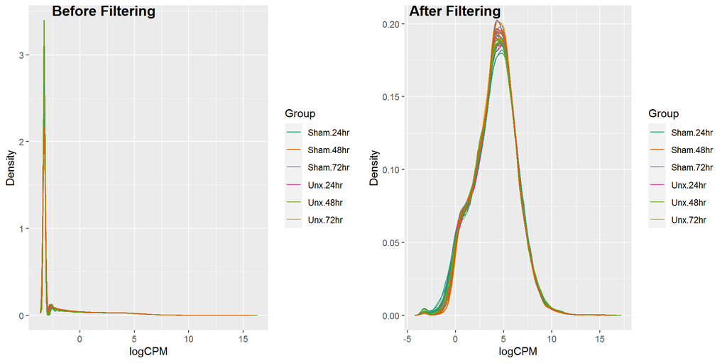

```r
## Compare the density distributions before and after filtering
BeforeFilt <- transCounts$counts %>%
cpm(log = TRUE) %>%
  as.data.frame() %>%
  pivot_longer(
    cols = everything(),
    names_to = "sample",
    values_to = "logCPM") %>%
  split(f = .$sample) %>%
  lapply(function(x){
    d <- density(x$logCPM)
    tibble(sample = unique(x$sample),
           x = d$x,y = d$y)}) %>%
  bind_rows() %>%
  left_join(samples) %>%
  ggplot(aes(x, y, colour = group, group = sample)) +
  geom_line() +
  scale_colour_manual(values = groupCols) +
  labs(x = "logCPM", y = "Density", colour = "Group")

AfterFilt<-dgeList %>%
cpm(log = TRUE) %>%
  as.data.frame() %>%
  pivot_longer(
    cols = everything(),
    names_to = "sample",
    values_to = "logCPM") %>%
  split(f = .$sample) %>%
  lapply(function(x){
    d <- density(x$logCPM)
    tibble(sample = unique(x$sample),
           x = d$x,y = d$y)}) %>%
  bind_rows() %>%
  left_join(samples) %>%
  ggplot(aes(x, y, colour = group, group = sample)) +
  geom_line() +
  scale_colour_manual(values = groupCols) +
  labs(x = "logCPM", y = "Density", colour = "Group")


plot_grid(BeforeFilt, AfterFilt, labels = c("Before Filtering","After Filtering"))
```

Initial library sizes were between *14,868,665* and *24,108,914* This dataset retained 13,158 genes for DGE analysis.

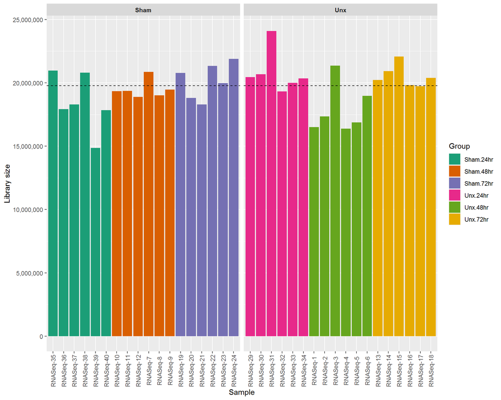

*Library Sizes after removal of undetectable genes and summarising to gene-level counts. Median library size is shown as the dashed line.*

### Additional Functions

```r
# contLabeller <- as_labeller(
#   c(KOVsWT = "-/- Vs +/+",
#     KO = "-/-",
#     WT = "+/+"))

contLabeller <- as_labeller(
  c(KO = "Sham Vs Unx"))

geneLabeller <- structure(grGenes$gene_name, names = grGenes$gene_id) %>%
  as_labeller()
```

Labeller functions for genotypes, contrasts and gene names were additionally defined for simpler plotting using `ggplot2`.

# Analysis

## Initial MDS

MDS: Project a multi-dimensional space preserving the inter-point distances

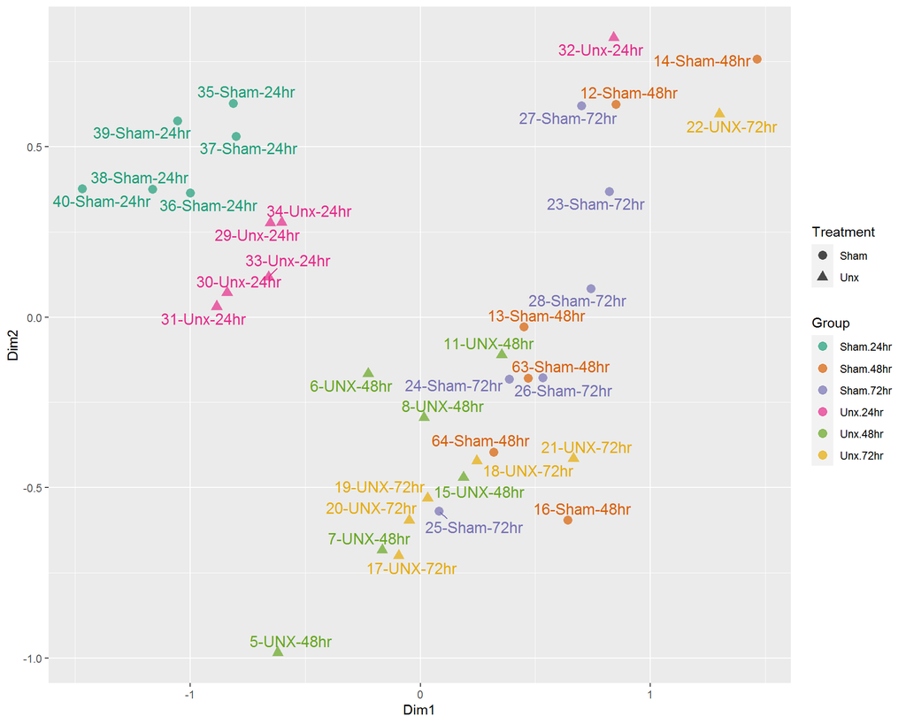

## Initial PCA

PCA: Project a multi-dimensional space onto the directions of maximum variability

```r
pca <- dgeList %>%
  cpm(log = TRUE) %>%
  t() %>%
  prcomp()
pcaVars <- percent_format(0.1)(summary(pca)$importance["Proportion of Variance",])
```

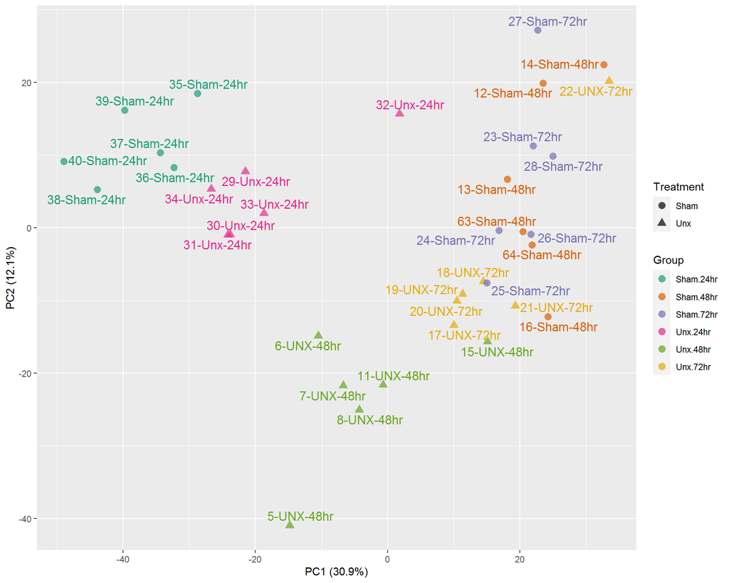

*PCA 1 & 2 of gene-level counts.*

```r
pca$x %>%
  as.data.frame() %>%
  rownames_to_column("sample") %>%
  as_tibble() %>%
  dplyr::select(sample, PC1, PC2) %>%
  left_join(dgeList$samples,"sample") %>%
  ggplot(aes(x=PC1, y=PC2, colour = group)) +
  geom_point(aes(shape=as.factor(treatment)),alpha = 0.7, size = 3) +
  geom_text_repel(aes(label = label), size=4.4, show.legend = FALSE) +
  # stat_ellipse(geom = "polygon", alpha = 0.1, show.legend = FALSE, aes(fill=group)) +
  #scale_shape_manual(values=c(15,11,19,17))+ #change shape
  scale_colour_manual(
    values = groupCols) +
  labs(
    x = paste0("PC1 (", pcaVars[["PC1"]], ")"),
    y = paste0("PC2 (", pcaVars[["PC2"]], ")"),
    colour = "Group",
    shape = "Treatment")
```

```r
options(ggrepel.max.overlaps = Inf)

pca12 <-pca$x %>%
  as.data.frame() %>%
  rownames_to_column("sample") %>%
  as_tibble() %>%
  dplyr::select(sample, PC1, PC2) %>%
  left_join(dgeList$samples,"sample") %>%
  ggplot(aes(x=PC1, y=PC2, colour = group)) +
  geom_point(aes(shape=as.factor(treatment)),alpha = 0.7, size = 3) +
  geom_text_repel(aes(label = label), size=3.5, show.legend = FALSE) +
  # stat_ellipse(geom = "polygon", alpha = 0.1, show.legend = FALSE, aes(fill=group)) +
  #scale_shape_manual(values=c(15,11,19,17))+ #change shape
  scale_colour_manual(
    values = groupCols) +
  labs(
    x = paste0("PC1 (", pcaVars[["PC1"]], ")"),
    y = paste0("PC2 (", pcaVars[["PC2"]], ")"),
    colour = "Group",
    shape = "Treatment") + theme(legend.position = c(1.2,0.5))
pca23 <-pca$x %>%
  as.data.frame() %>%
  rownames_to_column("sample") %>%
  as_tibble() %>%
  dplyr::select(sample, PC2, PC3) %>%
  left_join(dgeList$samples,"sample") %>%
  ggplot(aes(x=PC2, y=PC3, colour = group)) +
  geom_point(aes(shape=as.factor(treatment)),alpha = 0.7, size = 3) +
  geom_text_repel(aes(label = label), size=3.5, show.legend = FALSE) +
  # stat_ellipse(geom = "polygon", alpha = 0.1, show.legend = FALSE, aes(fill=group)) +
  #scale_shape_manual(values=c(15,11,19,17))+ #change shape
  scale_colour_manual(
    values = groupCols) +
  labs(
    x = paste0("PC2 (", pcaVars[["PC2"]], ")"),
    y = paste0("PC3 (", pcaVars[["PC3"]], ")"),
    colour = "Group",
    shape = "Treatment") + theme(legend.position = "none")
pca34 <-pca$x %>%
  as.data.frame() %>%
  rownames_to_column("sample") %>%
  as_tibble() %>%
  dplyr::select(sample, PC3, PC4) %>%
  left_join(dgeList$samples,"sample") %>%
  ggplot(aes(x=PC3, y=PC4, colour = group)) +
  geom_point(aes(shape=as.factor(treatment)),alpha = 0.7, size = 3) +
  geom_text_repel(aes(label = label), size=3.5, show.legend = FALSE) +
  # stat_ellipse(geom = "polygon", alpha = 0.1, show.legend = FALSE, aes(fill=group)) +
  #scale_shape_manual(values=c(15,11,19,17))+ #change shape
  scale_colour_manual(
    values = groupCols) +
  labs(
    x = paste0("PC3 (", pcaVars[["PC3"]], ")"),
    y = paste0("PC4 (", pcaVars[["PC4"]], ")"),
    colour = "Group",
    shape = "Treatment") +  theme(legend.position = "none")
```

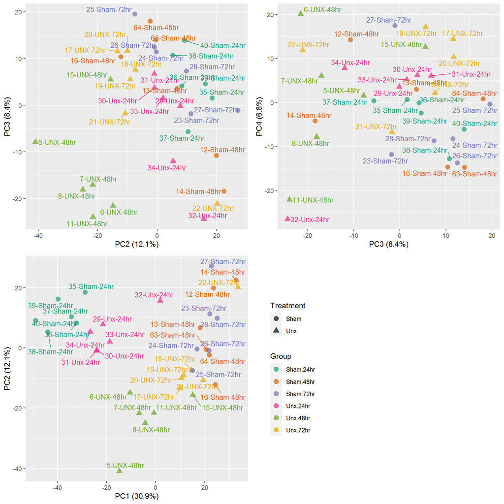

```r
library(grid)
vp1 <- viewport(x = 0.25, y = 0.25, width = 0.5, height = 0.5)
vp2 <- viewport(x = 0.25, y = 0.75, width = 0.5, height = 0.5)
vp3 <- viewport(x = 0.75, y = 0.75, width = 0.5, height = 0.5)
# Plot PCA plots in grid
if (interactive()) grid::grid.newpage()
print(pca12, vp = vp1)
print(pca23, vp = vp2)
print(pca34, vp = vp3)
```

A Principal Component Analysis (PCA) was performed using logCPM values from each sample. Samples appears to cluster together based on time point but with exception of several 48hrs samples.

## Differential Gene Expression

### Creating a design matrix and contrasts

```r
design <- model.matrix(~0+group, data=dgeList$samples)%>%
  set_colnames(str_remove(colnames(.), "group"))
design
```

```
##           Sham.24hr Sham.48hr Sham.72hr Unx.24hr Unx.48hr Unx.72hr
## RNASeq-1          0         0         0        0        1        0
## RNASeq-10         0         1         0        0        0        0
## RNASeq-11         0         1         0        0        0        0
## RNASeq-12         0         1         0        0        0        0
## RNASeq-13         0         0         0        0        0        1
## RNASeq-14         0         0         0        0        0        1
## RNASeq-15         0         0         0        0        0        1
## RNASeq-16         0         0         0        0        0        1
## RNASeq-17         0         0         0        0        0        1
## RNASeq-18         0         0         0        0        0        1
## RNASeq-19         0         0         1        0        0        0
## RNASeq-2          0         0         0        0        1        0
## RNASeq-20         0         0         1        0        0        0
## RNASeq-21         0         0         1        0        0        0
## RNASeq-22         0         0         1        0        0        0
## RNASeq-23         0         0         1        0        0        0
## RNASeq-24         0         0         1        0        0        0
## RNASeq-29         0         0         0        1        0        0
## RNASeq-3          0         0         0        0        1        0
## RNASeq-30         0         0         0        1        0        0
## RNASeq-31         0         0         0        1        0        0
## RNASeq-32         0         0         0        1        0        0
## RNASeq-33         0         0         0        1        0        0
## RNASeq-34         0         0         0        1        0        0
## RNASeq-35         1         0         0        0        0        0
## RNASeq-36         1         0         0        0        0        0
## RNASeq-37         1         0         0        0        0        0
## RNASeq-38         1         0         0        0        0        0
## RNASeq-39         1         0         0        0        0        0
## RNASeq-4          0         0         0        0        1        0
## RNASeq-40         1         0         0        0        0        0
## RNASeq-5          0         0         0        0        1        0
## RNASeq-6          0         0         0        0        1        0
## RNASeq-7          0         1         0        0        0        0
## RNASeq-8          0         1         0        0        0        0
## RNASeq-9          0         1         0        0        0        0
## attr(,"assign")
## [1] 1 1 1 1 1 1
## attr(,"contrasts")
## attr(,"contrasts")$group
## [1] "contr.treatment"
```

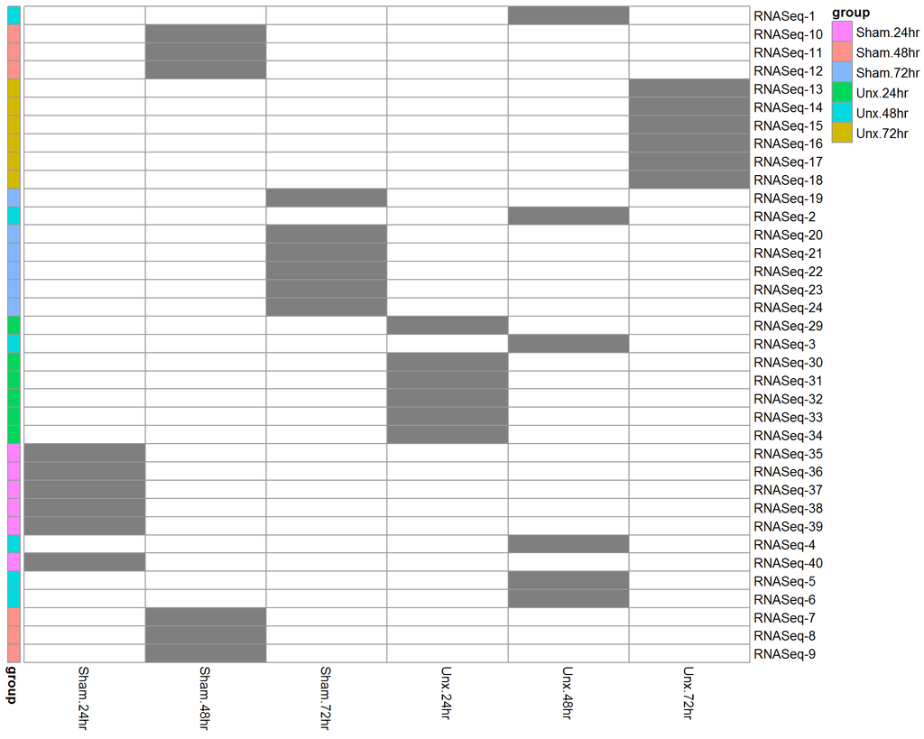

```r
pheatmap(
  design,
  cluster_cols = FALSE,
  cluster_rows = FALSE,
  color = c("white", "grey50"),
  annotation_row = dgeList$samples["group"],
  annotation_colors = list(condition = groupCols),
  legend = FALSE
)
```

```r
contr.matrix <- makeContrasts(
   Sham24vsUnx24 = Unx.24hr-Sham.24hr,
   Sham48vsUnx48 = Unx.48hr-Sham.48hr,
   Sham72vsUnx72 = Unx.72hr-Sham.72hr,
   ShamvsUnx = (Unx.24hr-Sham.72hr-Sham.24hr)-(Sham.48hr-Unx.72hr-Unx.48hr),
   Unx24vsUnx48 = Unx.48hr-Unx.24hr,
   Unx24vsUnx72 = Unx.72hr-Unx.24hr,
   Unx48vsUnx72 = Unx.72hr-Unx.48hr,
   Sham24vsSham48 = Sham.48hr-Sham.24hr,
   Sham24vsSham72 = Sham.72hr-Sham.24hr,
   Sham48vsSham72 = Sham.72hr-Sham.48hr,
   t24vst48 = (Sham.24hr-Unx.48hr)-(Unx.24hr-Sham.48hr),
   t24vst72 = (Unx.72hr-Sham.24hr)-(Unx.24hr-Sham.72hr),
   t48vst72 = (Unx.72hr-Sham.48hr)-(Unx.48hr-Sham.72hr),
   levels = colnames(design))
contr.matrix
```

```
##            Contrasts
## Levels      Sham24vsUnx24 Sham48vsUnx48 Sham72vsUnx72 ShamvsUnx Unx24vsUnx48
##   Sham.24hr            -1             0             0        -1            0
##   Sham.48hr             0            -1             0        -1            0
##   Sham.72hr             0             0            -1        -1            0
##   Unx.24hr              1             0             0         1           -1
##   Unx.48hr              0             1             0         1            1
##   Unx.72hr              0             0             1         1            0
##            Contrasts
## Levels      Unx24vsUnx72 Unx48vsUnx72 Sham24vsSham48 Sham24vsSham72
##   Sham.24hr            0            0             -1             -1
##   Sham.48hr            0            0              1              0
##   Sham.72hr            0            0              0              1
##   Unx.24hr            -1            0              0              0
##   Unx.48hr             0           -1              0              0
##   Unx.72hr             1            1              0              0
##            Contrasts
## Levels      Sham48vsSham72 t24vst48 t24vst72 t48vst72
##   Sham.24hr              0        1       -1        0
##   Sham.48hr             -1        1        0       -1
##   Sham.72hr              1        0        1        1
##   Unx.24hr               0       -1       -1        0
##   Unx.48hr               0       -1        0       -1
##   Unx.72hr               0        0        1        1
```

### Estimation of sample weights

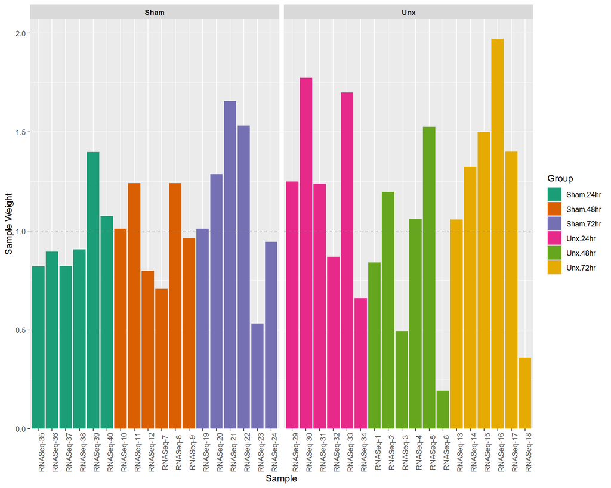

*Sample weights after voom transformation. The idealised equal weighting of $w = 1$ is shown as the dashed line.*

```r
v <- voomWithQualityWeights(dgeList, design, plot=FALSE)
```

Means (x-axis) and variances (y-axis) of each gene are plotted to show the dependence between the two before voom is applied to the data (left panel) and how the trend is removed after voom precision weights are applied to the data (right panel)

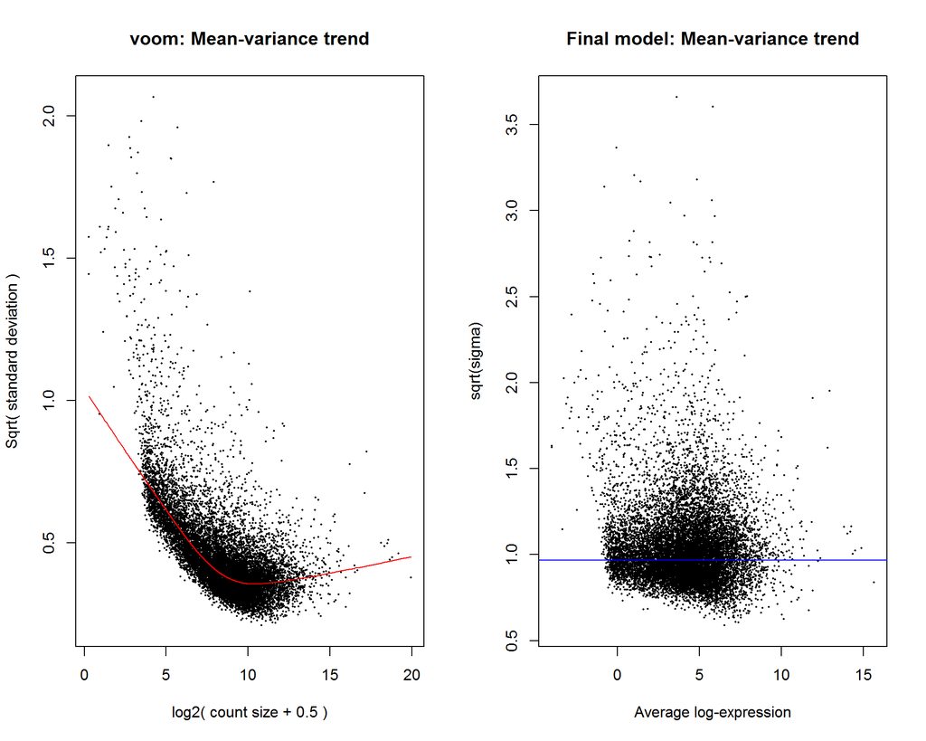

```r
par(mfrow=c(1,2))
v2 <- voom(dgeList, design, plot=TRUE)
v2fit <-lmFit(v2, design)
e2fit <-eBayes(v2fit)
plotSA(e2fit, main="Final model: Mean-variance trend")
```

### Strict Comparison between groups

```r
tau <- log2(1.1)
```

For the comparison between groups, a null hypothesis was tested using a range of values, instead of the point value zero, i.e.

$$H_0: -\tau < \Delta \mu < \tau \\
Vs. \\
H_A: | \Delta \mu | > \tau$$

The default value used in the function `treat()` is $\tau = \log_2 1.2$ and for this analysis, $\tau = \log_2 1.1$ was chosen as a suitable value.

```r
alpha <- 0.05

tfit <- lmFit(v,design) %>%
  contrasts.fit(contr.matrix) %>%
  treat(lfc = tau)
```

```r
summary(decideTests(tfit))
```

```
##        Sham24vsUnx24 Sham48vsUnx48 Sham72vsUnx72 ShamvsUnx Unx24vsUnx48
## Down             697          1767            47      1706         1224
## NotSig         11733          9569         13004      9527        10514
## Up               728          1822           107      1925         1420
##        Unx24vsUnx72 Unx48vsUnx72 Sham24vsSham48 Sham24vsSham72 Sham48vsSham72
## Down           1378         1443           2566           2526              0
## NotSig        10205        10296           7634           7699          13158
## Up             1575         1419           2958           2933              0
##        t24vst48 t24vst72 t48vst72
## Down       1497     3288      985
## NotSig    10515     5961    11257
## Up         1146     3909      916
```

```r
topTables <- colnames(contr.matrix) %>%
  sapply(function(x){
  topTreat(tfit, coef = x, n = Inf) %>%
      as_tibble() %>%
      rownames_to_column("No.") %>%
      arrange(P.Value) %>%
      mutate(DE= adj.P.Val < alpha,
             Status = case_when(
      DE ==TRUE & logFC < 0 ~ "Down",
      DE == TRUE & logFC > 0 ~ "Up"),
      Status = ifelse(is.na(Status), "NotSig", Status))}, simplify = FALSE)
```

Look for common genes between “Sham24vsUnx24” & “Sham48vsUnx48” & “Sham72vsUnx72”

```r
dt<-decideTests(tfit)
de.common <- which(dt[,1]!=0 & dt[,2]!=0 & dt[,3]!=0)
length(de.common)
```

```
## [1] 21
```

```r
head(tfit$genes$gene_name[de.common], n=339)
```

```
##  [1] "Mvd"      "Slc38a3"  "Plau"     "Enox1"    "Fitm1"    "Pkmyt1"
##  [7] "Psat1"    "Tuba4a"   "Nuf2"     "Slc25a25" "Slc52a3"  "Pck1"
## [13] "Kntc1"    "Slc25a36" "Slc16a1"  "Pik3ip1"  "Tubb4b"   "Mpped1"
## [19] "Slc16a6"  "Ttr"      "Pappa2"
```

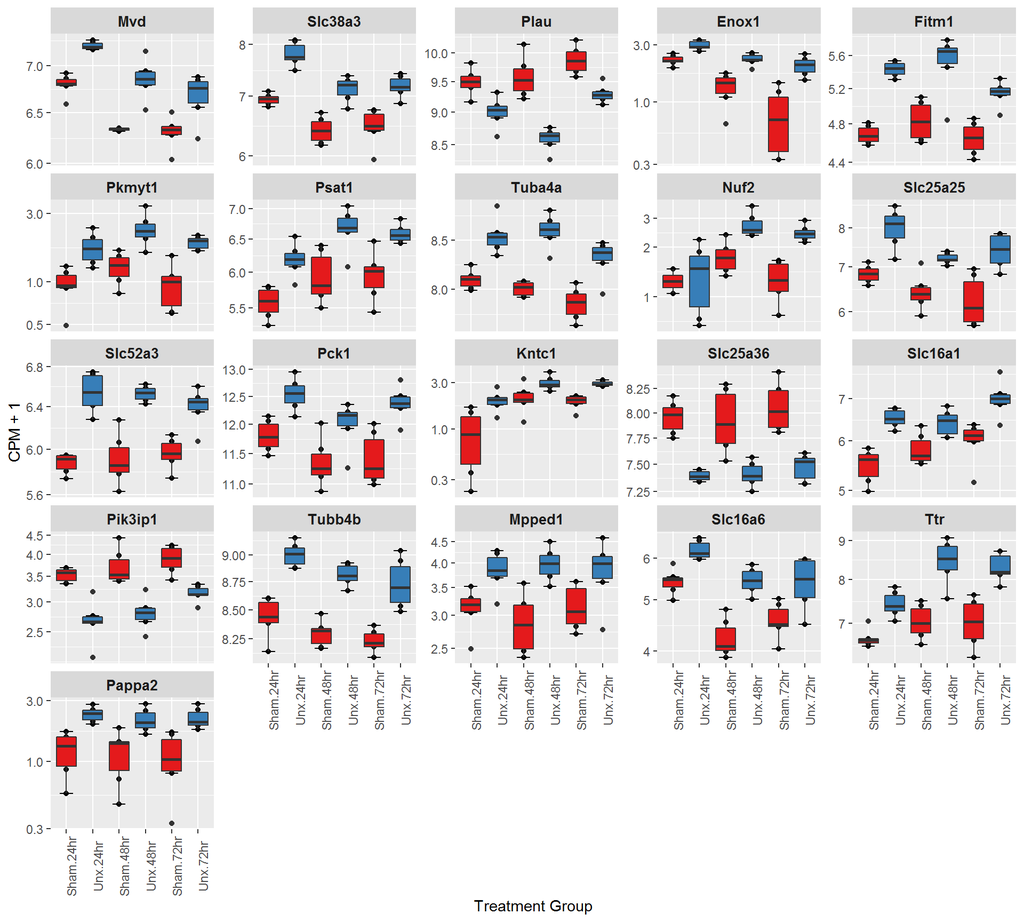

```r
cpm(dgeList, log=TRUE, prior.count = 3)[tfit$genes$gene_id[de.common],] %>%
  as.data.frame() %>%
  rownames_to_column("gene_id") %>%
    as_tibble() %>%
    gather(key = "sample", value = "CPM", -gene_id) %>%
    mutate(CPM = CPM + 1) %>%
    left_join(dgeList$samples) %>%
  mutate(treatment = fct_relevel(treatment, "Sham","Unx")) %>%
  mutate(group = fct_relevel(group, "Sham.24hr","Unx.24hr","Sham.48hr","Unx.48hr","Sham.72hr","Unx.72hr")) %>%
    ggplot(aes(group, CPM, fill = treatment)) +
  geom_point() +
    # geom_text_repel(aes(label = time)) +
  stat_boxplot(geom='errorbar', linetype=1, width=0.5)+
    geom_boxplot() +
    facet_wrap(
        ~gene_id,
        scales = "free_y",
        labeller = as_labeller(
            structure(dgeList$genes$gene_name, names = dgeList$genes$gene_id)
        )) + scale_fill_manual(values = treatCols) +
    scale_y_log10()  +
    labs(x = "Treatment Group",
         y = "CPM + 1") +
    theme(legend.position = "none",axis.text.x = element_text(angle = 90),
          strip.text = element_text(size= 10, face="bold"))
```

Look for common genes between “Sham24vsUnx24” & “Sham48vsUnx48”

```r
# dt<-decideTests(tfit)
# de.common <- which(dt[,1]!=0 & dt[,2]!=0)
# length(de.common)
# head(tfit$genes$gene_name[de.common], n=20)
```

```r
#Annotation colour for volcano plot
deCols <- c(
  'Up' = rgb(1, 0, 0, 1),
  'Down' = rgb(0, 0, 1, 1),
  'NotSig' = rgb(0.5, 0.5, 0.5, 0.7),
  `FALSE` = rgb(0.5, 0.5, 0.5, 0.7),
  `TRUE` = rgb(1, 0, 0, 0.7))
```